# Execise 03

2024-04-02

# Initialisation of libraries and dataset

## Import Libraries

```r
knitr::opts_chunk$set(tidy.opts=list(width.cutoff=60), format='latex', echo=TRUE)
library(tidyverse)
library(lubridate)
#install.packages('arrow', repos = c('https://apache.r-universe.dev'))
library(arrow)
```

## Import Dataset

```r
data_path <- "/Users/yuyichen/Desktop/Winter 2024/ORGB - 672/2024-ona-assignments/app_data_sample.parquet" # change this to your path
applications <- arrow::read_parquet(data_path)
```

```r
#install.packages("wru")
options(repos = c(CRAN = "https://cloud.r-project.org"))
```

# Processing of dataset to include gender and race for examiners

## Adding gender.y to dataset based on surnames library

```r
install.packages("gender")
library(gender)
library(githubinstall)
install.packages("remotes")
library(remotes)
```

```r
# get a list of first names without repetitions
library(gender)

# get a list of first names without repetitions
examiner_names <- applications %>%
  distinct(examiner_name_first)


examiner_names_gender <- examiner_names %>%
  do(results = gender(.$examiner_name_first, method = "ssa")) %>%
  unnest(cols = c(results), keep_empty = TRUE) %>%
  select(
    examiner_name_first = name,
    gender,
    proportion_female
  )

examiner_names_gender
```

| examiner_name_first | gender | proportion_female |
| --- | --- | --- |
| AARON | male | 0.0082 |
| ABDEL | male | 0.0000 |
| ABDOU | male | 0.0000 |
| ABDUL | male | 0.0000 |
| ABDULHAKIM | male | 0.0000 |
| ABDULLAH | male | 0.0000 |
| ABDULLAHI | male | 0.0000 |
| ABIGAIL | female | 0.9982 |
| ABIMBOLA | female | 0.9436 |
| ABRAHAM | male | 0.0031 |

[output cut: 1812 more lines]

```r
gc()
```

```
##            used  (Mb) gc trigger  (Mb) limit (Mb) max used  (Mb)
## Ncells  1655243  88.4    3097578 165.5         NA  2456212 131.2
## Vcells 16555617 126.4   31716731 242.0      16384 31604751 241.2
```

```r
# remove extra colums from the gender table
examiner_names_gender <- examiner_names_gender %>%
  select(examiner_name_first, gender)

# joining gender back to the dataset
applications <- applications %>%
  left_join(examiner_names_gender, by = "examiner_name_first")

# cleaning up
rm(examiner_names)
rm(examiner_names_gender)
gc()
```

```
##            used  (Mb) gc trigger  (Mb) limit (Mb) max used  (Mb)
## Ncells  4777131 255.2    8134592 434.5         NA  4796698 256.2
## Vcells 49913482 380.9   93485384 713.3      16384 80228372 612.1
```

## Adding race.y to dataset using surnames library

```r
library(wru)
examiner_surnames <- applications %>%
  select(surname = examiner_name_last) %>%
  distinct()


examiner_race <- predict_race(voter.file = examiner_surnames, surname.only = T) %>%
  as_tibble()
```

```
## Predicting race for 2020
```

```
## Proceeding with last name predictions...
```

```
## ℹ All local files already up-to-date!
```

```
## 701 (18.4%) individuals' last names were not matched.
```

```r
examiner_race <- examiner_race %>%
  mutate(max_race_p = pmax(pred.asi, pred.bla, pred.his, pred.oth, pred.whi)) %>%
  mutate(race = case_when(
    max_race_p == pred.asi ~ "Asian",
    max_race_p == pred.bla ~ "black",
    max_race_p == pred.his ~ "Hispanic",
    max_race_p == pred.oth ~ "other",
    max_race_p == pred.whi ~ "white",
    TRUE ~ NA_character_
  ))


examiner_race <- examiner_race %>%
  select(surname,race)

applications <- applications %>%
  left_join(examiner_race, by = c("examiner_name_last" = "surname"))

rm(examiner_race)
rm(examiner_surnames)
gc()
```

```
##            used  (Mb) gc trigger  (Mb) limit (Mb) max used  (Mb)
## Ncells  4904833 262.0    8134592 434.5         NA  6360586 339.7
## Vcells 52185166 398.2   93485384 713.3      16384 91661815 699.4
```

## Adding dates-related data to calculate tenure days

```r
library(lubridate) # to work with dates

examiner_dates <- applications %>%
  select(examiner_id, filing_date, appl_status_date)
examiner_dates <- examiner_dates %>%
  mutate(start_date = ymd(filing_date), end_date = as_date(dmy_hms(appl_status_date)))

examiner_dates <- examiner_dates %>%
  group_by(examiner_id) %>%
  summarise(
    earliest_date = min(start_date, na.rm = TRUE),
    latest_date = max(end_date, na.rm = TRUE),
    tenure_days = interval(earliest_date, latest_date) %/% days(1)
    ) %>%
  filter(year(latest_date)<2018)
applications <- applications %>%
  left_join(examiner_dates, by = "examiner_id")

rm(examiner_dates)
gc()
```

```
##            used  (Mb) gc trigger   (Mb) limit (Mb)  max used  (Mb)
## Ncells  4913600 262.5    8134592  434.5         NA   8134592 434.5
## Vcells 58260999 444.5  134794952 1028.5      16384 111629391 851.7
```

# Creating panel data

## Cleaning noisy data

```r
library(dplyr)

# Assuming 'applications' is the correct dataframe and includes the 'gender' column as listed
distinct_dataset <- applications %>%
  select(examiner_art_unit, examiner_id, gender, race, tenure_days) %>%
  distinct()
distinct_dataset <- distinct_dataset %>%
  mutate(first_three_digits = str_sub(examiner_art_unit, 1, 3))
```

## Select Workgroup 172 and 173

```r
filtered_df <- distinct_dataset %>%
  filter(str_sub(examiner_art_unit, 1, 3) %in% c("172", "173"))
```

### Statistics Summary of Workgroup

```r
# Summary statistics for tenure
tenure_summary <- filtered_df %>%
  group_by(workgroup = str_sub(examiner_art_unit, 1, 3)) %>%
  summarise(
    count = n(),
    mean_tenure = mean(tenure_days, na.rm = TRUE),
    sd_tenure = sd(tenure_days, na.rm = TRUE),
    min_tenure = min(tenure_days, na.rm = TRUE),
    max_tenure = max(tenure_days, na.rm = TRUE)
  )

print(tenure_summary)
```

```
## # A tibble: 2 × 6
##   workgroup count mean_tenure sd_tenure min_tenure max_tenure
##   <chr>     <int>       <dbl>     <dbl>      <dbl>      <dbl>
## 1 172         286       5107.     1437.        435       6350
## 2 173         235       5311.     1301.        251       6391
```

```r
# Frequency tables for gender and race
gender_table <- table(filtered_df$first_three_digits, filtered_df$gender)
race_table <- table(filtered_df$first_three_digits, filtered_df$race)

print(gender_table)
```

```
##
##       female male
##   172     84  168
##   173     72  140
```

```r
print(race_table)
```

```
##
##       Asian black Hispanic white
##   172    57     4        9   216
##   173    48     6        8   173
```

### Racial Composition

As the frequency table for race shows, in workgroup ‘172’, there are more white employees (216) than all other racial categories combined (70). Workgroup ‘173’ has a similar racial makeup, with white employees (173) outnumbering other racial groups. The bar chart representing the proportion of white employees showcases that workgroup ‘172’ and ‘173’ have higher percentages of white employees compared to the ‘Other’ group.

### Visual Statistics of “Male” and “White” resepctively from the 172 and 173 Group

```r
library(dplyr)
library(stringr)

distinct_dataset <- distinct_dataset %>%
  mutate(group = case_when(
    str_sub(examiner_art_unit, 1, 3) == "171" ~ "172",
    str_sub(examiner_art_unit, 1, 3) == "172" ~ "173",
    TRUE ~ "Other"
  ))

# Proportion of male employees
female_prop <- distinct_dataset %>%
  group_by(group) %>%
  summarise(male_count = sum(gender == "male", na.rm = TRUE),
            total_count = n(),
            prop_male = male_count / total_count)

# Proportion of white employees
white_prop <- distinct_dataset %>%
  group_by(group) %>%
  summarise(white_count = sum(race == "white", na.rm = TRUE),
            total_count = n(),
            prop_white = white_count / total_count)

print(female_prop)
```

```
## # A tibble: 3 × 4
##   group male_count total_count prop_male
##   <chr>      <int>       <int>     <dbl>
## 1 172          150         260     0.577
## 2 173          168         286     0.587
## 3 Other       5754        9967     0.577
```

```r
print(white_prop)
```

```
## # A tibble: 3 × 4
##   group white_count total_count prop_white
##   <chr>       <int>       <int>      <dbl>
## 1 172           187         260      0.719
## 2 173           216         286      0.755
## 3 Other        6257        9967      0.628
```

### Visualize Tenure by Workroup

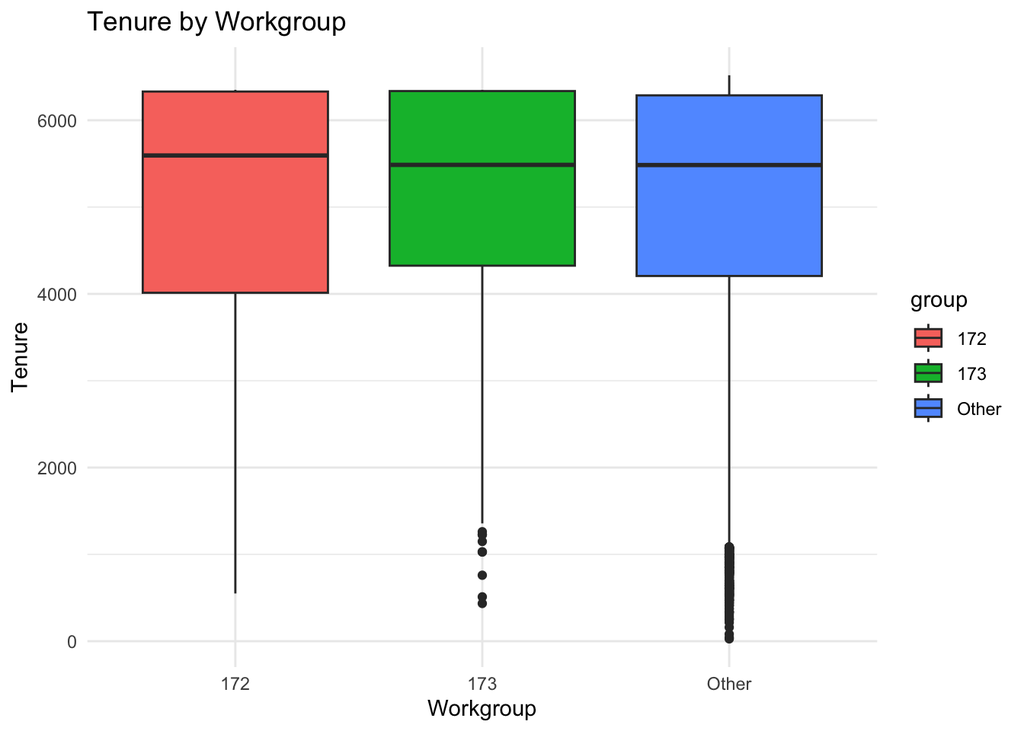

```r
library(ggplot2)

# Boxplot for tenure by workgroup
ggplot(distinct_dataset, aes(x = group, y = tenure_days, fill = group)) +
  geom_boxplot() +
  labs(x = "Workgroup", y = "Tenure", title = "Tenure by Workgroup") +
  theme_minimal()
```

### Tenture Analysis

Workgroup ‘172’ has 286 members with an average tenure of approximately 5107 days and a standard deviation of about 1436 days. This indicates a tenure range from 435 days to 6350 days, suggesting a mix of relatively new and very experienced employees.

Workgroup ‘173’ has 235 members with a higher average tenure of approximately 5310 days, and a standard deviation of about 1300 days, indicating a somewhat less varied length of service compared to ‘172’. The minimum and maximum tenures span from 251 days to 6391 days, again highlighting a range from newer to highly tenured individuals.

### Visualize Proportion of Male Employees by Workgroup

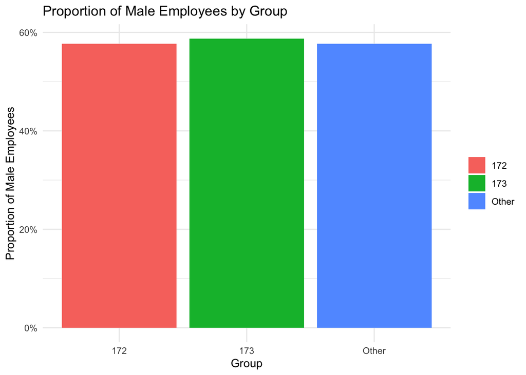

```r
df_prop <- distinct_dataset %>%
  group_by(group) %>%
  summarise(total_count = n(), # Total employees in each group
            male_count = sum(gender == "male", na.rm = TRUE)) %>%
  mutate(proportion_male = male_count / total_count) %>%
  select(group, proportion_male)


ggplot(df_prop, aes(x = group, y = proportion_male, fill = group)) +
  geom_col() + # geom_col is equivalent to geom_bar(stat = "identity") but more intuitive for this use case
  scale_y_continuous(labels = scales::percent_format()) +
  labs(x = "Group", y = "Proportion of Male Employees", title = "Proportion of Male Employees by Group") +
  theme_minimal() +
  theme(legend.title = element_blank())
```

### Visualize Proportion of White Employees by Group

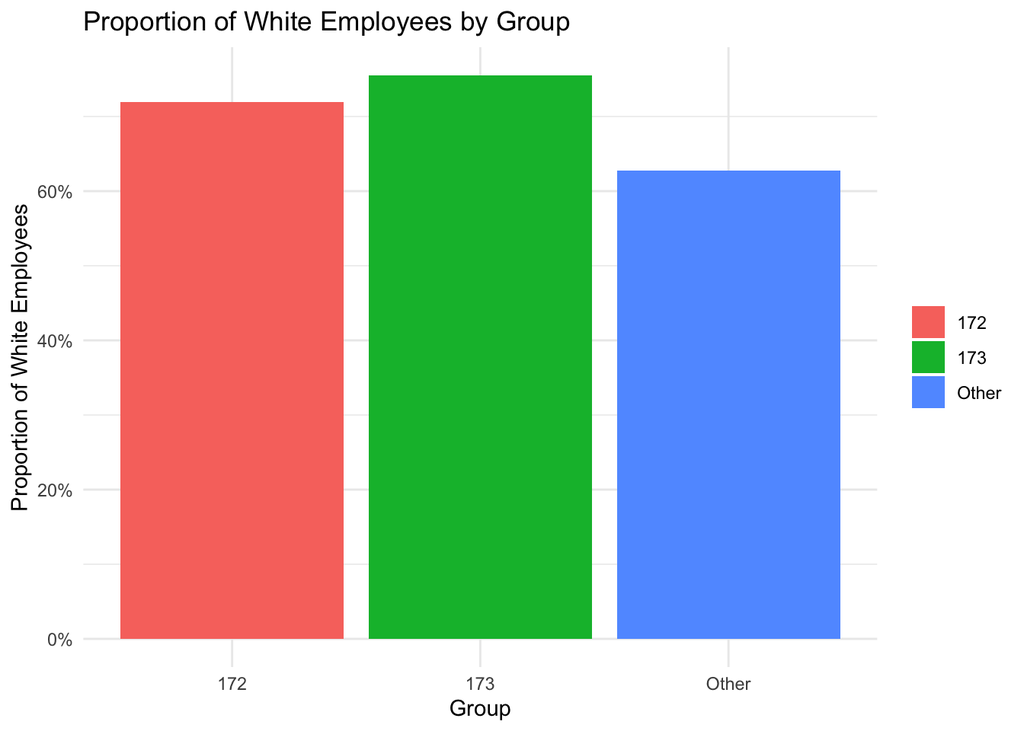

```r
df_prop <- distinct_dataset %>%
  group_by(group) %>%
  summarise(total_count = n(), # Total employees in each group
            white_count = sum(race == "white", na.rm = TRUE)) %>%
  mutate(proportion_white = white_count / total_count) %>%
  select(group, proportion_white)


ggplot(df_prop, aes(x = group, y = proportion_white, fill = group)) +
  geom_col() + # geom_col is equivalent to geom_bar(stat = "identity") but more intuitive for this use case
  scale_y_continuous(labels = scales::percent_format()) +
  labs(x = "Group", y = "Proportion of White Employees", title = "Proportion of White Employees by Group") +
  theme_minimal() +
  theme(legend.title = element_blank())
```

### Conclusions

The analysis suggests that workgroups ‘172’ and ‘173’ not only exhibit disparities in gender and racial demographics but also show differences in tenure distributions. Both groups are male-dominated and primarily composed of white employees, with ‘173’ showing a slightly higher average tenure than ‘172’. The distribution of tenure indicates a workforce with a range of experiences, from newer employees to those with many years of service. This diversity in tenure could be beneficial for fostering a workplace that balances fresh perspectives with institutional knowledge.

### Network Graph Building

```r
edges_sample <- read_csv("/Users/yuyichen/Desktop/Winter 2024/ORGB - 672/2024-ona-assignments/edges_sample.csv")
filtered_examiners <- distinct_dataset %>%
  filter(group %in% c("172","173"))
```

### Building Network Graph for Workgroup 172 and 173

```r
library(igraph)
library(readr)
edges_for_network <- edges_sample %>%
  filter(ego_examiner_id %in% filtered_examiners$examiner_id | alter_examiner_id %in% filtered_examiners$examiner_id)
network <- graph_from_data_frame(edges_for_network, directed = TRUE)


library(visNetwork)
visNetwork::visIgraph(network)
```

[interactive chart not shown]

### Network Graph Analysis for Workgroups 172 and 173

#### Clustering Patterns

The network graph shows distinct clusters, indicating that within both workgroups, there are subgroups where members interact more intensively with each other. This suggests the presence of homophily, where shared characteristics or job functions might lead to tighter bonds within these clusters.

#### Central Nodes as Influencers

Noticeably, certain nodes serve as central hubs with numerous connections. In workgroup 172, if these hubs are scattered throughout the network, it could point to a decentralized structure with shared leadership and collaborative influence. In contrast, if workgroup 173’s central nodes create a tight core, it may indicate a conventional hierarchy where a few individuals hold most of the influence.

#### Peripheral Engagement

On the graph’s edges, nodes with sparse connections likely represent individuals in peripheral roles within the workgroups. These members may be less integrated into the main workflow, potentially due to the newness to the group, specialized job functions, or lower requirements for collaborative interaction.

#### Bridging Figures

Nodes situated between clusters may represent key connectors, bridging different subgroups within the workgroups. For workgroup 172, this could be emblematic of cross-functional collaboration, suggesting a fluid exchange of ideas and resources. For workgroup 173, such nodes might be essential for communication across more siloed departments.

#### Isolation and Integration

Isolated nodes, or those with minimal connections, stand out as atypical within the network. They could be remote workers, new hires, or individuals whose roles are isolated by nature. Their positioning warrants attention to ensure they’re not inadvertently excluded from vital communication channels.

#### Conclusion on the Network Analysis

This graph analysis illuminates the social fabric within the workgroups. It underscores diverse degrees of collaboration and communication, with central figures, connectors, and isolated nodes each playing distinct roles. For organizational development, these insights are invaluable, directing focus toward enhancing the integration of peripheral members, supporting the roles of central influencers, and optimizing the bridging capabilities between clusters to achieve a harmonious and efficient network ecosystem.

### The Centrality Measure - Closeness Centrality

Centrality Measure Justification: Closeness centrality is utilized in the analysis as it quantitatively captures the average distance of an individual to all others in the network, which offers a measure of how integrated or central an individual is within the broader organizational structure.

### Calculation of CLoseness centrality for Workgroup 172 only

```r
filtered_172_df <- distinct_dataset %>%
  filter(str_sub(examiner_art_unit, 1, 3) %in% c("172"))
```

### The Average Closeness Centrality by Gender for Workgroup 172

```r
# Calculation of closeness centrality for 172
closeness_centrality <- closeness(network, mode = "out")
centrality_scores <- data.frame(examiner_id = V(network)$name,
                                closeness_centrality = closeness_centrality) %>%
  mutate(examiner_id = as.numeric(examiner_id))

# Join the centrality scores with the filtered dataset for workgroup 172
final_dataset_172 <- filtered_172_df %>%
  left_join(centrality_scores, by = "examiner_id")

# Calculate the average closeness centrality by gender for workgroup 172
average_by_gender_172 <- final_dataset_172 %>%
  group_by(gender) %>%
  summarise(average_closeness_centrality = mean(closeness_centrality, na.rm = TRUE))

# Display the table
print(average_by_gender_172)
```

```
## # A tibble: 3 × 2
##   gender average_closeness_centrality
##   <chr>                         <dbl>
## 1 female                        0.253
## 2 male                          0.246
## 3 <NA>                          0.232
```

### The Average Closeness Centrality by Race for Workgroup 172

```r
average_by_race_172 <- final_dataset_172 %>%
  group_by(race) %>%
  summarise(average_closeness_centrality = mean(closeness_centrality, na.rm = TRUE))
print(average_by_race_172)
```

```
## # A tibble: 4 × 2
##   race     average_closeness_centrality
##   <chr>                           <dbl>
## 1 Asian                           0.150
## 2 Hispanic                        0.334
## 3 black                           0.2
## 4 white                           0.274
```

### The Average Closeness Centrality by Tenture Category for Workgroup 172

```r
library(dplyr)
# Define bins for tenure days. Adjust the breaks as needed for your dataset.
tenure_bins <- c(0, 365, 730, 1095, 1460, Inf) # Example bins: <1 year, 1-2 years, 2-3 years, 3-4 years, >4 years
labels <- c("<1 year", "1-2 years", "2-3 years", "3-4 years", ">4 years") # Labels for the bins

# Create a new column for tenure categories in the filtered_172_df dataframe
final_dataset_172 <- final_dataset_172 %>%
  mutate(tenure_category = cut(tenure_days, breaks = tenure_bins, labels = labels, right = FALSE))

# Calculate average closeness centrality score grouped by tenure category for workgroup 172
average_by_tenure_category_172 <- final_dataset_172 %>%
  group_by(tenure_category) %>%
  summarise(average_closeness_centrality = mean(closeness_centrality, na.rm = TRUE))

# Display the table
print(average_by_tenure_category_172)
```

```
## # A tibble: 5 × 2
##   tenure_category average_closeness_centrality
##   <fct>                                  <dbl>
## 1 1-2 years                            NaN
## 2 2-3 years                            NaN
## 3 3-4 years                            NaN
## 4 >4 years                               0.246
## 5 <NA>                                 NaN
```

```r
filtered_173_df <- distinct_dataset %>%
  filter(str_sub(examiner_art_unit, 1, 3) %in% c("173"))
```

### The Average Closeness Centrality by Gender for Workgroup 173

```r
# Calculation of closeness centrality
closeness_centrality <- closeness(network, mode = "out")
centrality_scores <- data.frame(examiner_id = V(network)$name,
                                closeness_centrality = closeness_centrality) %>%
  mutate(examiner_id = as.numeric(examiner_id))

# Join the centrality scores with the filtered dataset for workgroup 172
final_dataset_173 <- filtered_173_df %>%
  left_join(centrality_scores, by = "examiner_id")

# Calculate the average closeness centrality by gender for workgroup 172
average_by_gender_173 <- final_dataset_173 %>%
  group_by(gender) %>%
  summarise(average_closeness_centrality = mean(closeness_centrality, na.rm = TRUE))

# Display the table
print(average_by_gender_173)
```

```
## # A tibble: 3 × 2
##   gender average_closeness_centrality
##   <chr>                         <dbl>
## 1 female                        0.295
## 2 male                          0.390
## 3 <NA>                          0.489
```

### The Average Closeness Centrality by Race for Workgroup 173

```r
average_by_race_173 <- final_dataset_173 %>%
  group_by(race) %>%
  summarise(average_closeness_centrality = mean(closeness_centrality, na.rm = TRUE))
print(average_by_race_173)
```

```
## # A tibble: 4 × 2
##   race     average_closeness_centrality
##   <chr>                           <dbl>
## 1 Asian                           0.418
## 2 Hispanic                        0.472
## 3 black                           0.162
## 4 white                           0.391
```

### The Average Closeness Centrality by Tenture Category for Workgroup 173

```r
library(dplyr)
# Define bins for tenure days. Adjust the breaks as needed for your dataset.
tenure_bins <- c(0, 365, 730, 1095, 1460, Inf) # Example bins: <1 year, 1-2 years, 2-3 years, 3-4 years, >4 years
labels <- c("<1 year", "1-2 years", "2-3 years", "3-4 years", ">4 years") # Labels for the bins

# Create a new column for tenure categories in the filtered_172_df dataframe
final_dataset_173 <- final_dataset_173 %>%
  mutate(tenure_category = cut(tenure_days, breaks = tenure_bins, labels = labels, right = FALSE))

# Calculate average closeness centrality score grouped by tenure category for workgroup 172
average_by_tenure_category_173 <- final_dataset_173 %>%
  group_by(tenure_category) %>%
  summarise(average_closeness_centrality = mean(closeness_centrality, na.rm = TRUE))

# Display the table
print(average_by_tenure_category_173)
```

```
## # A tibble: 6 × 2
##   tenure_category average_closeness_centrality
##   <fct>                                  <dbl>
## 1 <1 year                              NaN
## 2 1-2 years                            NaN
## 3 2-3 years                            NaN
## 4 3-4 years                            NaN
## 5 >4 years                               0.391
## 6 <NA>                                 NaN
```

### Relationship Analysis

#### Gender-Based Centrality in Workgroups:

Analysis of workgroup ‘172’ reveals a subtle gender influence on centrality, with female examiners marginally more central than their male counterparts. This suggests the presence of gender homophily—women might be leveraging their connections within the group for support and collaboration in a subtly different way than men. In workgroup ‘173’, a more pronounced centrality among male examiners indicates disparate networking behaviors or opportunities that can be linked to gender.